# Pettitt Test Report

The **Pettitt Test** is used to identify abrupt changes in the mean of a time series.

- Null Hypothesis: There are no abrupt changes in the time series mean.
- Alternative Hypothesis: There is *one* abrupt change in the time series mean.

Define $\text{sign} (x)$ to be $1$ if $x > 0$, $0$ if $x = 0$, and $-1$ otherwise.

Given a time series $y_{1}, \dots, y_{n}$, compute the following test statistic:

$$U_{t} = \sum_{i=1}^{t} \sum_{j=t+1}^{n} \text{sign} (y_{j} - y_{i}),
\quad K = \max_{t}|U_{t}|$$

The value of $t$ such that $U_{t} = K$ is a **Potential Change Point**. The $p$-value of the potential change point can be approximated using the following formula for a one-sided test:

$$p \approx \exp \left(-\frac{6K^2}{n^3 + n^2}\right)$$

If $p$ is less than the significance level $\alpha$, we reject the null hypothesis and conclude that there is evidence for an abrupt change in the mean at the potential change point.

## Results

### Code

```r
# Mann-Whitney-Pettitt hypothesis test for abrupt changes in the mean
#  - ams: A vector of annual maximum streamflow data with no NA values
#  - year: A vector of years correspodning to ams with no NA values
#  - alpha: The significance level as a floating point number
pettitt_test <- function(ams, year, alpha = 0.05) {

    # Extract the length of ams for convenience
    n <- length(ams)

    # Compute the U-statistic for all t-values from 1 to n
    u_t <- numeric(n)

    for (t in 1:n) {
        u <- 0

        # u_t = sum(sign(ams[j] - ams[i])) for all i <= t, j > t
        for (i in 1:t) {
            for (j in min(t + 1, n):n) {
                u = u + sign(ams[j] - ams[i])
            }
        }

        u_t[t] = abs(u)
    }

    # The K-statistic is the maximum absolute value of the U-statistics
    k_statistic <- max(u_t)

    # Compute the p-value using an approximate formula
    p_value <- round(exp((-6 * k_statistic^2) / (n^3 + n^2)), digits=3)

    # Find the minimum statistically significant K-statistic
    k_alpha <- (-log(alpha) * ((n^3) + (n^2)) / 6)^0.5;

    # Determine the change index if the change is statistically significant
    reject <- (p_value <= alpha)
    change_index <- ifelse(reject, which.max(u_t), 0)
    change_year <- ifelse(reject, year[change_index], 0)
    print(change_year)

    # Print the results of the test
    message(glue("\n\nThe Pettitt test yielded a p-value of {round(p_value, 3)}."))

    if (reject) {
        output1 <- "reject"
        output2 <- glue("evidence of a change point at {change_year}")
    } else {
        output1 <- "fail to reject"
        output2 <- "NO evidence of a change point"
    }

    message(glue("At significance level {alpha}, we {output1} the null hypothesis."))
    message(glue("Therefore, there is {output2}."))

    # Return a list containing the results of the test
    mget(c(
        "u_t",
        "k_statistic",
        "k_alpha",
        "p_value",
        "change_index",
        "change_year",
        "reject"
    ))

}
```

### Statistics

- K-statistic: 1871
- P-value: 0
- Significance level: 0.05

Given the p-value and significance level, we REJECT the null hypothesis.

There is evidence of a abrupt change point in 1972.

### Figure

```r
library(ggplot2)
library(patchwork)

# Source the plot theme (path is relative to /source)
source("helpers/plot-theme.R")


# Plot the results of the Mann-Whitney-Pettitt test for abrupt changes in the mean
pettitt_plot <- function(df, results, show_trend) {

    # Load the results of the test into the environment
    list2env(results, envir = environment())

    # Add u_t to df and create change point df (if change point is significant)
    df$u_t = u_t
    change_df <- df[change_index, ]

    # Get the segment endpoints depending on whether there is a change point
    n <- length(u_t)
    ends <- if (change_index == 0) c(1, n) else c(1, change_index, n)

    n_ends <- length(ends)
    get_segment_mean <- function(i) mean(df$max[ends[i]:ends[i + 1]])

    # Compute the segment means for the plot
    segment_df <- data.frame(
        x = df$year[ends[-n_ends]],
        xend = df$year[ends[-1]],
        y = sapply(1:(n_ends - 1), get_segment_mean)
    )

    # Generate the labels with proper formatting
    ut_label <- expression(U[t] ~ Statistic)
    flow_label <- expression(AMS ~ m^3/s)

    # First subplot: Mann-Whitney-Pettitt Test
    p1 <- ggplot(df, aes(x = year, y = u_t)) +
        geom_line(aes(color = "black"), linewidth = 1.2) +
        geom_hline(
            aes(yintercept = k_alpha, color = "red"),
            linewidth = 1.2,
            linetype = "dashed",
        ) +
        geom_point(data = change_df, aes(color = "blue"), size = 4) +
        labs(
            title = "Mann-Whitney-Pettitt Test",
            x = "Year",
            y = ut_label,
            color = "Legend") +
        scale_color_manual(
            values = c("black" = "black", "red" = "red", "blue" = "blue"),
            breaks = c("black", "red", "blue"),
            labels = c(ut_label, "Change Point Threshold", "Potential Change Point")
        )

    # Also plot the original flow data and segment means
    p2 <- ggplot(df, aes(x = year, y = max)) +
        geom_point(aes(color = "black"), size = 2.25) +
        (if (show_trend) geom_line(color = "black", linewidth = 1.1) else NULL) +
        geom_segment(
            data = segment_df,
            aes(x = x, xend = xend, y = y, color = "green4"),
            linewidth = 1.2
        ) +
        geom_point(data = change_df, aes(color = "blue"), size = 4) +
        labs(x = "Year", y = flow_label, color = "Legend") +
        scale_color_manual(
            values = c("black" = "black", "green4" = "green4", "blue" = "blue"),
            breaks = c("black", "green4", "blue"),
            labels = c(flow_label, "Segment Mean(s)", "Potential Change Point")
        )

    # Stack plots on top of each other and return
    add_theme(p1) / add_theme(p2)

}
```

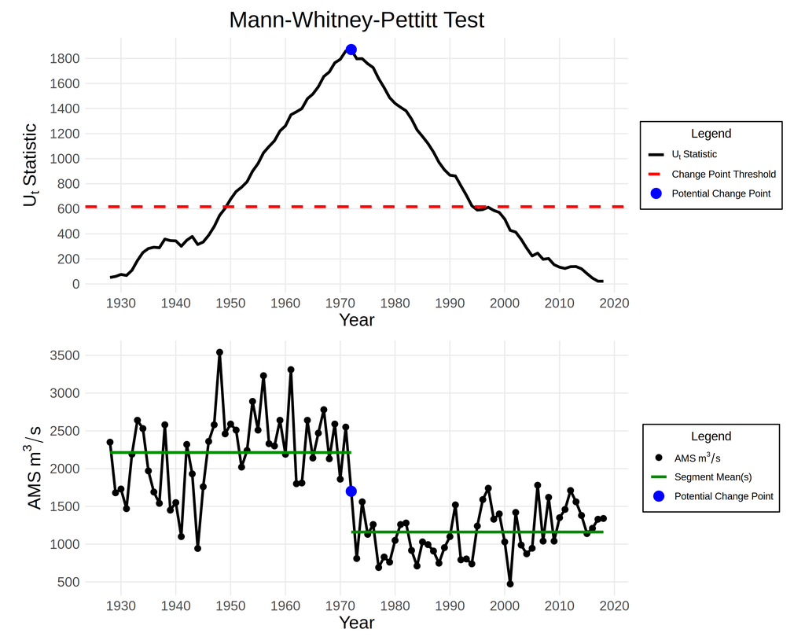